# Data Science for Business: Homework Assignment

Gyorgy Jablonszky

February 28, 2016

### **Bank Marketing Data Set**

#### Downloaded from UCI Machine Learning Repository

#### Source: http://archive.ics.uci.edu/ml/datasets/Bank+Marketing.

#### This dataset is public available for research. The details are described in S. Moro, P. Cortez and P. Rita. A Data-Driven Approach to Predict the Success of Bank Telemarketing. Decision Support Systems, Elsevier, 62:22-31, June 2014

### Introduction

This dataset provides unformation of telemarketing campaigns pursued by a Portuguese bank. Aim of current analysis is to predict whether a client would subscribe for a term deposit (yes/no). There are 20 input variables and a binary output variable.

**For this assignment I decided to mark all code chunks in the documentation in order to track processes step-by-step.**

#### Set libraries

```r
library(readr)
library(dplyr)
library(reshape2)
library(ggplot2)
library(pander)
library(h2o)

library(knitr)
opts_knit$set(root.dir = "../")
```

### Read data and review data structure

```r
bank <- read.csv("C:/Users/Szaffi/Desktop/Gyurma/Data_Science_for_Business/bank-additional/bank-additional-full.csv", sep=";") # specify directory or URL as data soruce
```

I decided to randomly reorder data at this early stage

```r
bank <- bank[sample(1:nrow(bank)), ]
```

Our variables are the following (with the outpur variable *y* at the 21th place):

```r
colnames(bank)
```

```
##  [1] "age"            "job"            "marital"        "education"
##  [5] "default"        "housing"        "loan"           "contact"
##  [9] "month"          "day_of_week"    "duration"       "campaign"
## [13] "pdays"          "previous"       "poutcome"       "emp.var.rate"
## [17] "cons.price.idx" "cons.conf.idx"  "euribor3m"      "nr.employed"
## [21] "y"
```

Let’s have a look at the structure of our data. We have 20 predictors and 1 output variable and altogether 41188 observations.

```r
dim(bank)
```

```
## [1] 41188    21
```

```r
str(bank)
```

```
## 'data.frame':    41188 obs. of  21 variables:
##  $ age           : int  34 34 58 43 53 44 33 39 26 47 ...
##  $ job           : Factor w/ 12 levels "admin.","blue-collar",..: 5 1 6 11 10 4 7 10 8 2 ...
##  $ marital       : Factor w/ 4 levels "divorced","married",..: 2 2 3 2 2 2 2 2 3 1 ...
##  $ education     : Factor w/ 8 levels "basic.4y","basic.6y",..: 7 4 6 6 4 1 3 6 4 3 ...
##  $ default       : Factor w/ 3 levels "no","unknown",..: 1 1 1 1 1 2 1 1 1 2 ...
##  $ housing       : Factor w/ 3 levels "no","unknown",..: 1 1 3 1 3 3 1 3 3 1 ...
##  $ loan          : Factor w/ 3 levels "no","unknown",..: 3 1 1 3 1 1 1 1 1 3 ...
##  $ contact       : Factor w/ 2 levels "cellular","telephone": 2 2 1 1 1 1 2 2 2 2 ...
##  $ month         : Factor w/ 10 levels "apr","aug","dec",..: 7 7 1 2 2 4 5 7 7 5 ...
##  $ day_of_week   : Factor w/ 5 levels "fri","mon","thu",..: 4 1 5 5 4 5 1 1 1 4 ...
##  $ duration      : int  234 172 1288 120 231 103 330 159 123 258 ...
##  $ campaign      : int  5 2 3 1 1 1 1 1 2 2 ...
##  $ pdays         : int  999 999 999 999 999 999 999 999 999 999 ...
##  $ previous      : int  0 0 0 0 0 0 0 0 0 0 ...
##  $ poutcome      : Factor w/ 3 levels "failure","nonexistent",..: 2 2 2 2 2 2 2 2 2 2 ...
##  $ emp.var.rate  : num  1.1 1.1 -1.8 1.4 1.4 1.4 1.4 1.1 1.1 1.4 ...
##  $ cons.price.idx: num  94 94 93.1 93.4 93.4 ...
##  $ cons.conf.idx : num  -36.4 -36.4 -47.1 -36.1 -36.1 -42.7 -41.8 -36.4 -36.4 -41.8 ...
##  $ euribor3m     : num  4.86 4.86 1.4 4.96 4.97 ...
##  $ nr.employed   : num  5191 5191 5099 5228 5228 ...
##  $ y             : Factor w/ 2 levels "no","yes": 1 1 2 1 1 1 1 1 1 1 ...
```

It may be useful to prepare some very basic descriptive statistics at this early stage of the data analysis project on raw data set. As one can see below there are categories like ‘unknownn’ and ‘other’ at many variables. We keep it in mind for later steps.

```r
pander(summary(bank))
```

Table continues below

| age | job | marital | education |
| --- | --- | --- | --- |
| Min. :17.00 | admin. :10422 | divorced: 4612 | university.degree :12168 |
| 1st Qu.:32.00 | blue-collar: 9254 | married :24928 | high.school : 9515 |
| Median :38.00 | technician : 6743 | single :11568 | basic.9y : 6045 |
| Mean :40.02 | services : 3969 | unknown : 80 | professional.course: 5243 |
| 3rd Qu.:47.00 | management : 2924 | NA | basic.4y : 4176 |
| Max. :98.00 | retired : 1720 | NA | basic.6y : 2292 |
| NA | (Other) : 6156 | NA | (Other) : 1749 |

Table continues below

| default | housing | loan | contact | month |
| --- | --- | --- | --- | --- |
| no :32588 | no :18622 | no :33950 | cellular :26144 | may :13769 |
| unknown: 8597 | unknown: 990 | unknown: 990 | telephone:15044 | jul : 7174 |
| yes : 3 | yes :21576 | yes : 6248 | NA | aug : 6178 |
| NA | NA | NA | NA | jun : 5318 |
| NA | NA | NA | NA | nov : 4101 |
| NA | NA | NA | NA | apr : 2632 |
| NA | NA | NA | NA | (Other): 2016 |

Table continues below

| day_of_week | duration | campaign | pdays | previous |
| --- | --- | --- | --- | --- |
| fri:7827 | Min. : 0.0 | Min. : 1.000 | Min. : 0.0 | Min. :0.000 |
| mon:8514 | 1st Qu.: 102.0 | 1st Qu.: 1.000 | 1st Qu.:999.0 | 1st Qu.:0.000 |
| thu:8623 | Median : 180.0 | Median : 2.000 | Median :999.0 | Median :0.000 |
| tue:8090 | Mean : 258.3 | Mean : 2.568 | Mean :962.5 | Mean :0.173 |
| wed:8134 | 3rd Qu.: 319.0 | 3rd Qu.: 3.000 | 3rd Qu.:999.0 | 3rd Qu.:0.000 |
| NA | Max. :4918.0 | Max. :56.000 | Max. :999.0 | Max. :7.000 |
| NA | NA | NA | NA | NA |

Table continues below

| poutcome | emp.var.rate | cons.price.idx | cons.conf.idx |
| --- | --- | --- | --- |
| failure : 4252 | Min. :-3.40000 | Min. :92.20 | Min. :-50.8 |
| nonexistent:35563 | 1st Qu.:-1.80000 | 1st Qu.:93.08 | 1st Qu.:-42.7 |
| success : 1373 | Median : 1.10000 | Median :93.75 | Median :-41.8 |
| NA | Mean : 0.08189 | Mean :93.58 | Mean :-40.5 |
| NA | 3rd Qu.: 1.40000 | 3rd Qu.:93.99 | 3rd Qu.:-36.4 |
| NA | Max. : 1.40000 | Max. :94.77 | Max. :-26.9 |
| NA | NA | NA | NA |

| euribor3m | nr.employed | y |
| --- | --- | --- |
| Min. :0.634 | Min. :4964 | no :36548 |
| 1st Qu.:1.344 | 1st Qu.:5099 | yes: 4640 |
| Median :4.857 | Median :5191 | NA |
| Mean :3.621 | Mean :5167 | NA |
| 3rd Qu.:4.961 | 3rd Qu.:5228 | NA |
| Max. :5.045 | Max. :5228 | NA |
| NA | NA | NA |

#### Now, let’s have a quick look at data itself checking the first 3 elements of each features

```r
pander(head(bank, 3))
```

Table continues below

|  | age | job | marital | education | default | housing |
| --- | --- | --- | --- | --- | --- | --- |
| **4262** | 34 | management | married | university.degree | no | no |
| **7356** | 34 | admin. | married | high.school | no | no |
| **30047** | 58 | retired | single | professional.course | no | yes |

Table continues below

|  | loan | contact | month | day_of_week | duration | campaign | pdays |
| --- | --- | --- | --- | --- | --- | --- | --- |
| **4262** | yes | telephone | may | tue | 234 | 5 | 999 |
| **7356** | no | telephone | may | fri | 172 | 2 | 999 |
| **30047** | no | cellular | apr | wed | 1288 | 3 | 999 |

Table continues below

|  | previous | poutcome | emp.var.rate | cons.price.idx |
| --- | --- | --- | --- | --- |
| **4262** | 0 | nonexistent | 1.1 | 93.99 |
| **7356** | 0 | nonexistent | 1.1 | 93.99 |
| **30047** | 0 | nonexistent | -1.8 | 93.08 |

|  | cons.conf.idx | euribor3m | nr.employed | y |
| --- | --- | --- | --- | --- |
| **4262** | -36.4 | 4.856 | 5191 | no |
| **7356** | -36.4 | 4.864 | 5191 | no |
| **30047** | -47.1 | 1.405 | 5099 | yes |

#### Check NAs and less than 0 values

```r
sapply(bank, function(x) sum(is.na(x)))
```

```
##            age            job        marital      education        default
##              0              0              0              0              0
##        housing           loan        contact          month    day_of_week
##              0              0              0              0              0
##       duration       campaign          pdays       previous       poutcome
##              0              0              0              0              0
##   emp.var.rate cons.price.idx  cons.conf.idx      euribor3m    nr.employed
##              0              0              0              0              0
##              y
##              0
```

```r
sapply(bank, function(x) sum(x<0, na.rm=TRUE))
```

```
##            age            job        marital      education        default
##              0              0              0              0              0
##        housing           loan        contact          month    day_of_week
##              0              0              0              0              0
##       duration       campaign          pdays       previous       poutcome
##              0              0              0              0              0
##   emp.var.rate cons.price.idx  cons.conf.idx      euribor3m    nr.employed
##          17191              0          41188              0              0
##              y
##              0
```

As we will see later there are some variables with ‘unknown’ values (not equal to NAs). There are two variables with negative values by default (*emp.var.rate and cons.conf_idx*).

### Variables in data set

#### **Target variable: Y** (*binary: ‘Yes’ / ‘No’*)

This variables shows whether the customer subscribed for a term deposit.

```r
pander(bank %>% group_by(y) %>% summarize(n = n()) %>% mutate(percentage = n/sum(n)*100))
```

| y | n | percentage |
| --- | --- | --- |
| no | 36548 | 88.73458 |
| yes | 4640 | 11.26542 |

More than 11% of customers subscribed for term deposit that altogether means 4640 observations.

#### Input variables - predictors

##### **Age** (*numeric*)

This variable provides information on customer’s age in years

```r
pander(summary(bank$age))
```

| Min. | 1st Qu. | Median | Mean | 3rd Qu. | Max. |
| --- | --- | --- | --- | --- | --- |
| 17 | 32 | 38 | 40.02 | 47 | 98 |

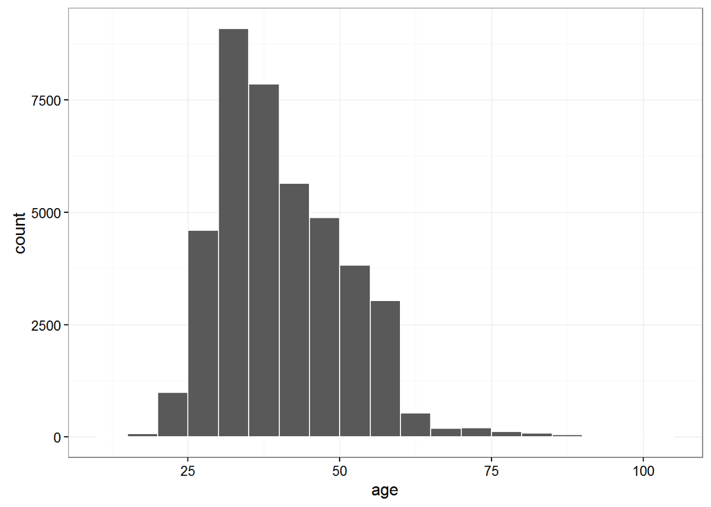

```r
ggplot(bank, aes(x = age)) + geom_histogram(binwidth = 5, col = "white") + theme_bw()
```

An important question whether to exclude observations under or above a specified treshold. We have 5 observations with an age below 18 years and 10 with higher than 90. I decided to exclude these rows according to relatively high probability of data error.

```r
nrow(bank[bank$age < 18, ])
```

```
## [1] 5
```

```r
nrow(bank[bank$age > 90, ])
```

```
## [1] 10
```

```r
bank <- bank %>% filter(age >= 18)
bank <- bank %>% filter(age < 90)
dim(bank)
```

```
## [1] 41173    21
```

As age variable shows a slightly skewed distribution with a right tail I decided to try taking logs and check distibution of log values as well.

```r
bank$lnage <- log(bank$age)
pander(summary(bank$lnage))
```

| Min. | 1st Qu. | Median | Mean | 3rd Qu. | Max. |
| --- | --- | --- | --- | --- | --- |
| 2.89 | 3.466 | 3.638 | 3.657 | 3.85 | 4.489 |

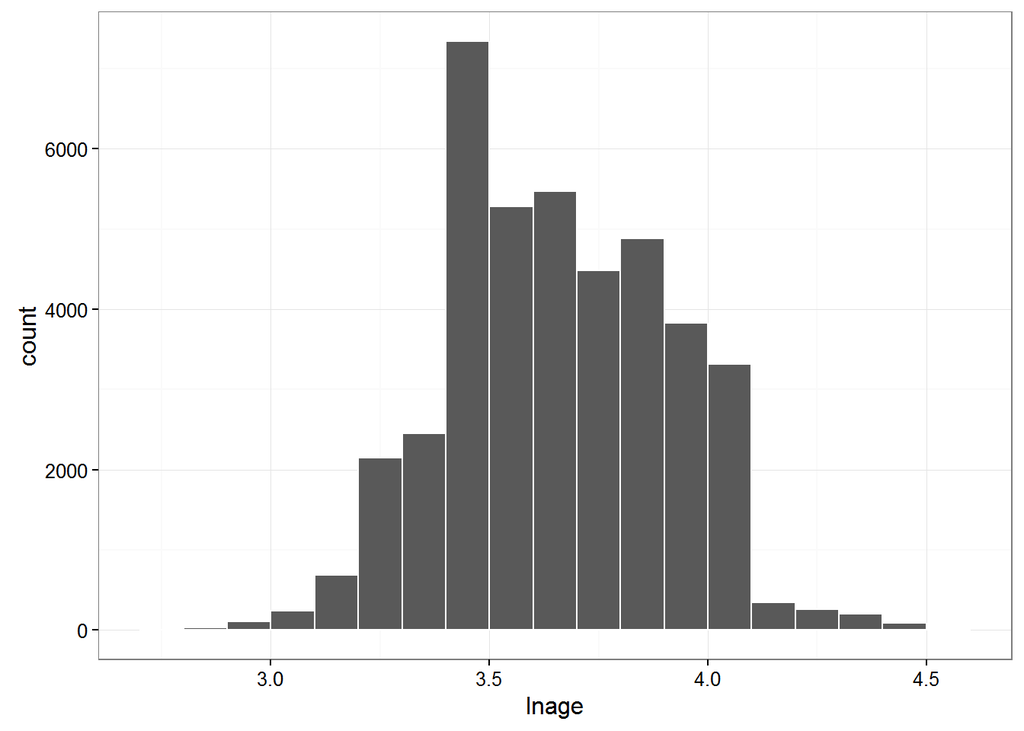

```r
ggplot(bank, aes(x = lnage)) + geom_histogram(binwidth = 0.1, col = "white") + theme_bw()
```

Let’s have a look at ages by the target variable:

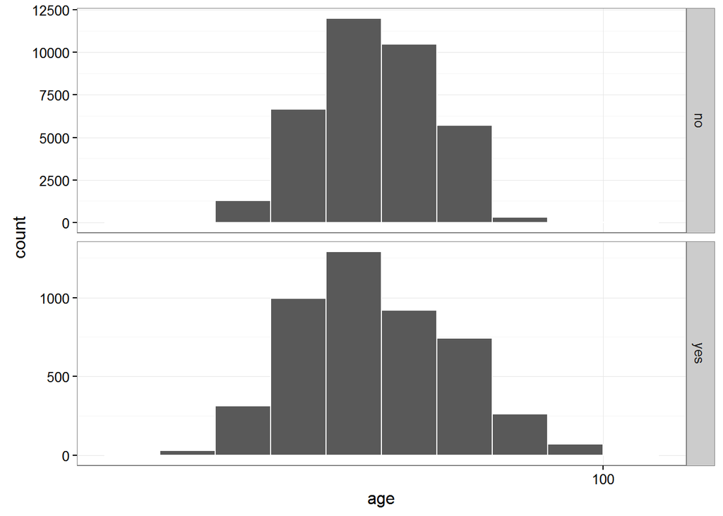

```r
ggplot(bank) + geom_histogram(aes(x = age), binwidth = 0.1, col = "white") +
  facet_grid(y~., scales = "free") + scale_x_log10() + theme_bw()
```

##### **Job** (*categorical*)

Job variable gives information on the job profile of targeted customers. There are 11 specified and 1 unspecified categories.

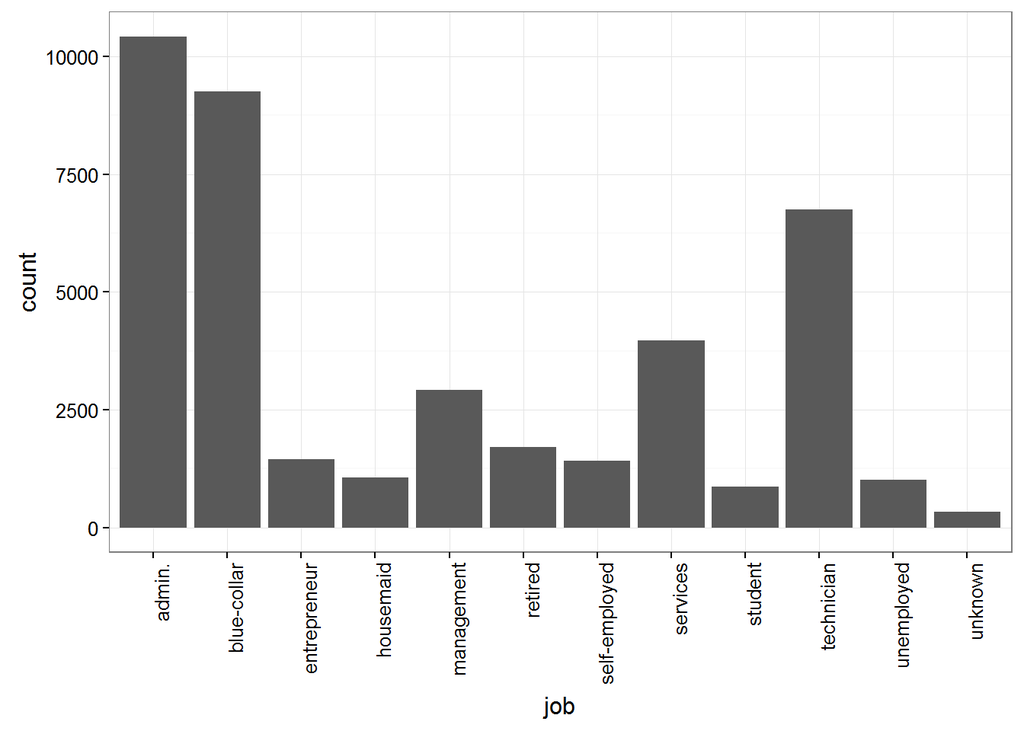

```r
ggplot(bank, aes(x = job)) + geom_bar() + theme_bw() + theme(axis.text.x = element_text(angle = 90, hjust = 1))
```

```r
nrow(bank[bank$job =="unknown", ])
```

```
## [1] 330
```

All observations are listed under the 12 categories with 330 unknown. In order to enhance accuracy finally I decided to exclude observations with unknown job category.

```r
bank <- bank %>% filter(job != "unknown")
```

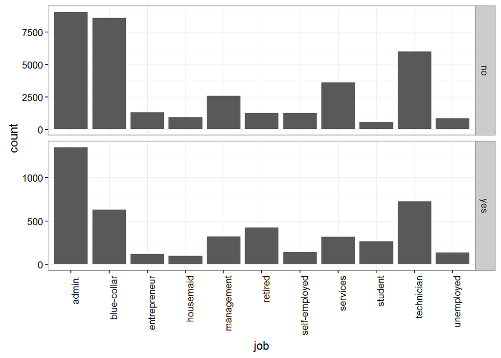

```r
ggplot(bank) + geom_bar(aes(x = job), col = "white") +
  facet_grid(y~., scales = "free")  + theme_bw() + theme(axis.text.x = element_text(angle = 90, hjust = 1))
```

##### **Marital** (*categorical*)

Marital status feature contains 4 categories as follows:

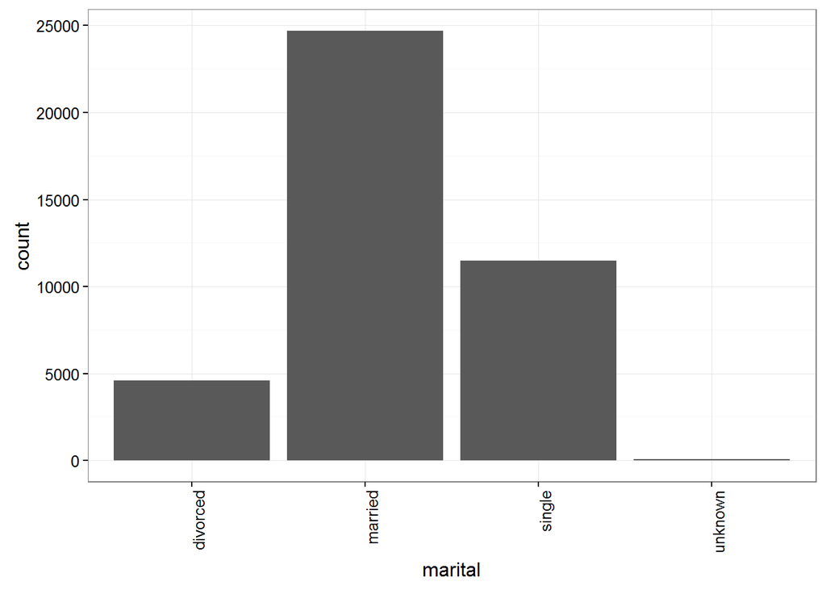

```r
ggplot(bank, aes(x = marital)) + geom_bar() + theme_bw() + theme(axis.text.x = element_text(angle = 90, hjust = 1))
```

```r
nrow(bank[bank$marital =="unknown", ])
```

```
## [1] 71
```

```r
bank <- bank %>% filter(marital != "unknown")
```

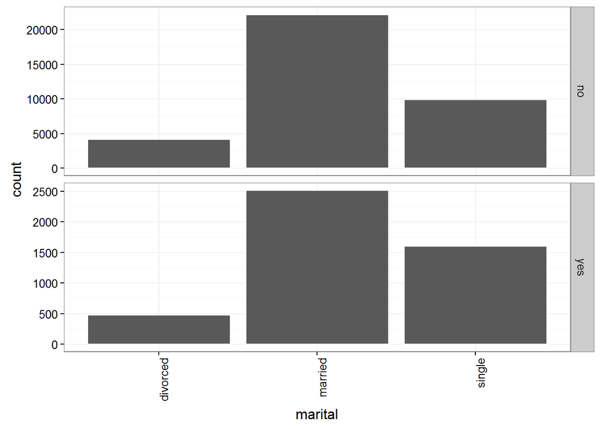

```r
ggplot(bank) + geom_bar(aes(x = marital), col = "white") +
  facet_grid(y~., scales = "free")  + theme_bw() + theme(axis.text.x = element_text(angle = 90, hjust = 1))
```

##### **Education** (*categorical*)

Education is also a categorical variable with 7 categories + 1 unknown.

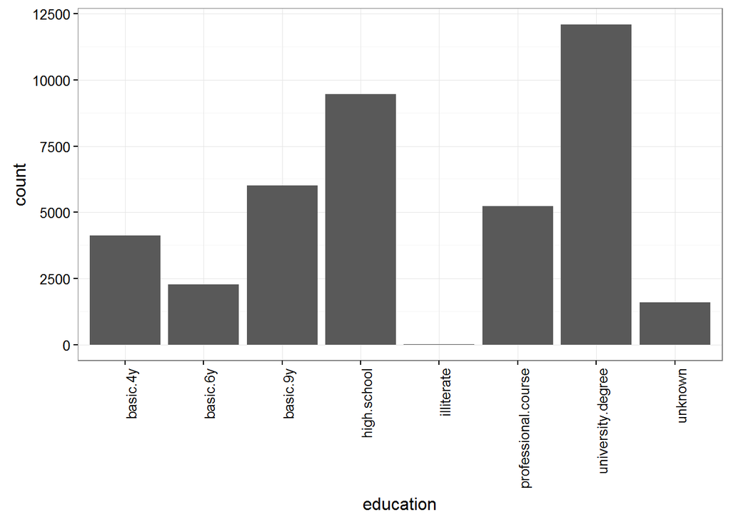

```r
ggplot(bank, aes(x = education)) + geom_bar() + theme_bw() + theme(axis.text.x = element_text(angle = 90, hjust = 1))
```

```r
nrow(bank[bank$education =="unknown", ])
```

```
## [1] 1590
```

```r
nrow(bank[bank$education =="illiterate", ])
```

```
## [1] 18
```

In case of education variable number of unknkown observations is pretty high. In order to decide whether to exclude them let’s check education by our target variable.

By eyeballing I decide now not to exclude observations concerned as their ratio ssems to be similar in both cases of decisions.

On the other hand I decided to exclude those 18 observations that are listed in the illiteral category.

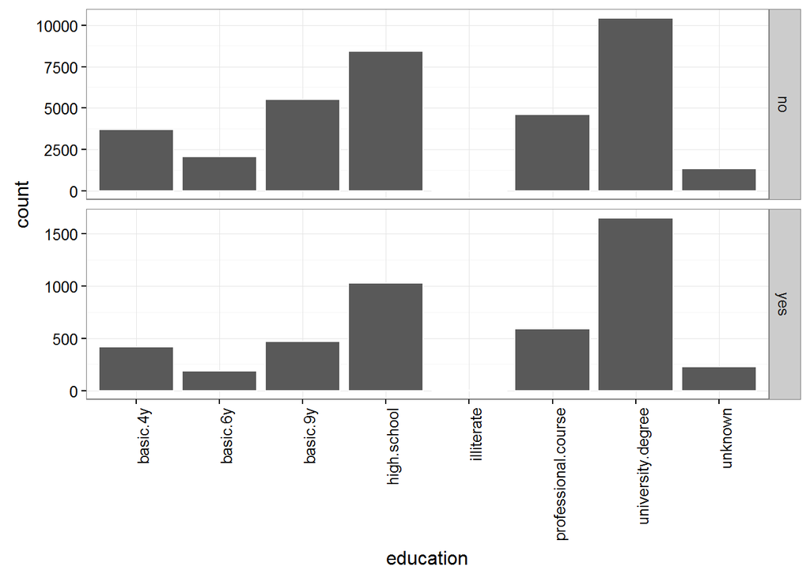

```r
ggplot(bank) + geom_bar(aes(x = education), col = "white") +
  facet_grid(y~., scales = "free")  + theme_bw() + theme(axis.text.x = element_text(angle = 90, hjust = 1))
```

```r
bank <- bank %>% filter(education != "illiterate")
```

##### **Default** (*categorical*)

This variable shows whether the targeted customer has a credit in default. There are 3 categories: a binary yes/no and the unknown that seems to be an issue as about 20% of customers are in the latter category.

```r
nrow(bank[bank$default =="unknown", ])
```

```
## [1] 8426
```

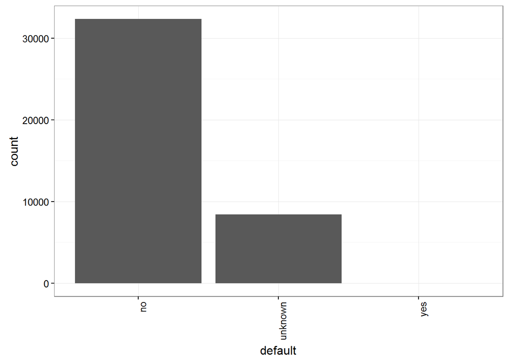

```r
ggplot(bank, aes(x = default)) + geom_bar() + theme_bw() + theme(axis.text.x = element_text(angle = 90, hjust = 1))
```

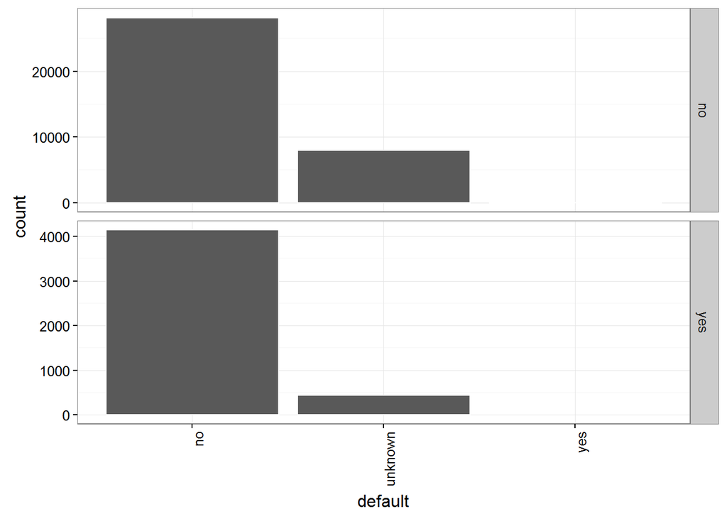

```r
ggplot(bank) + geom_bar(aes(x = default), col = "white") +
  facet_grid(y~., scales = "free")  + theme_bw() + theme(axis.text.x = element_text(angle = 90, hjust = 1))
```

```r
nrow(bank[bank$default =="yes", ])
```

```
## [1] 3
```

As number of obsevations with yes is negligable I suppose that its an exclusion to have a credit in default. 3 exceptions are probably errors that will be excluded. Unknown observations, however, will not be excluded due to their relatively high proportion.

```r
bank <- bank %>% filter(default != "yes")
```

##### **Housing** (*categorical*)

This variable shows whether the targeted customer has a housing loan. Here we also have 3 categories: a binary yes/no and the unknown.

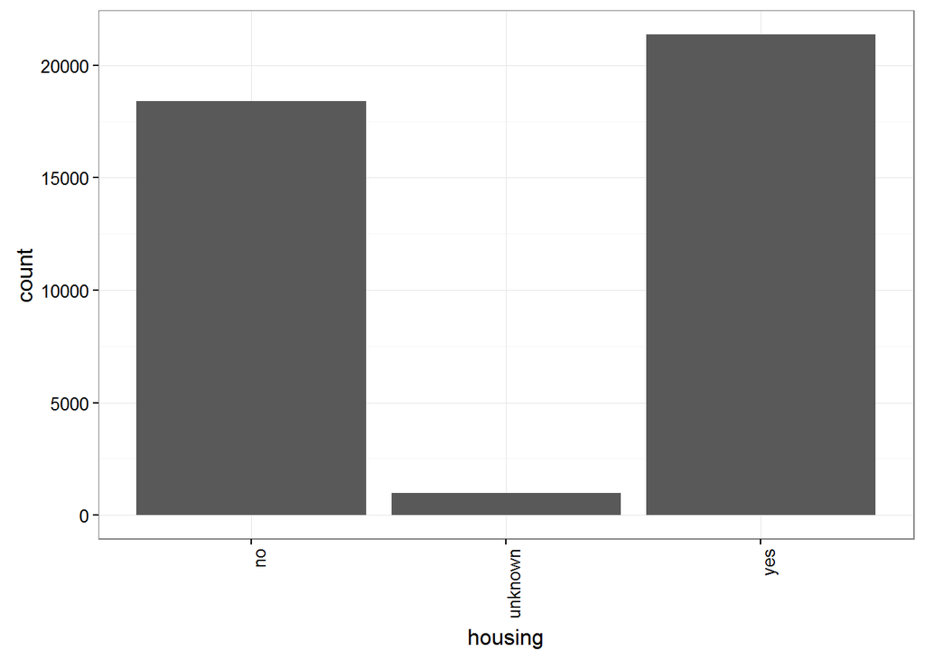

```r
ggplot(bank, aes(x = housing)) + geom_bar() + theme_bw() + theme(axis.text.x = element_text(angle = 90, hjust = 1))
```

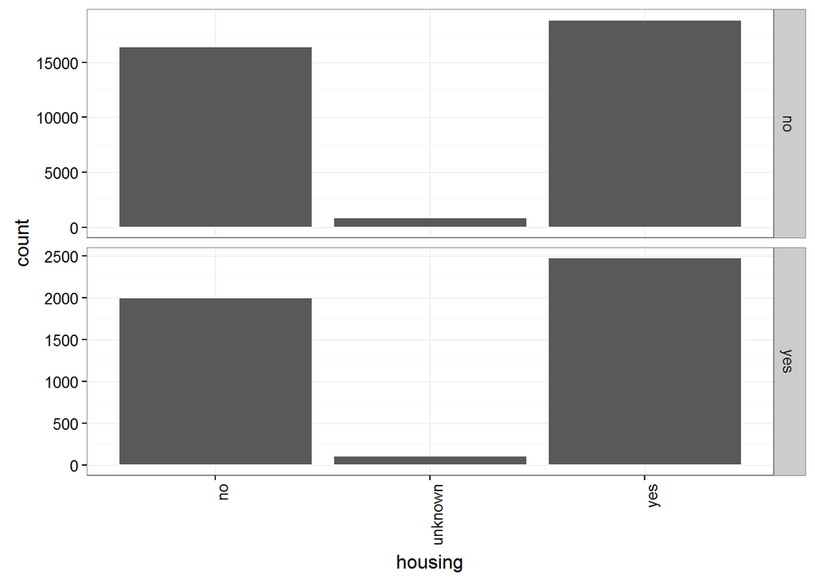

```r
ggplot(bank) + geom_bar(aes(x = housing), col = "white") +
  facet_grid(y~., scales = "free")  + theme_bw() + theme(axis.text.x = element_text(angle = 90, hjust = 1))
```

Let’s remove unknown.

```r
bank <- bank %>% filter(housing != "unknown")
```

##### **Loan** (*categorical*)

Whether the targeted customer has a personal loan (yes/no/unknown).

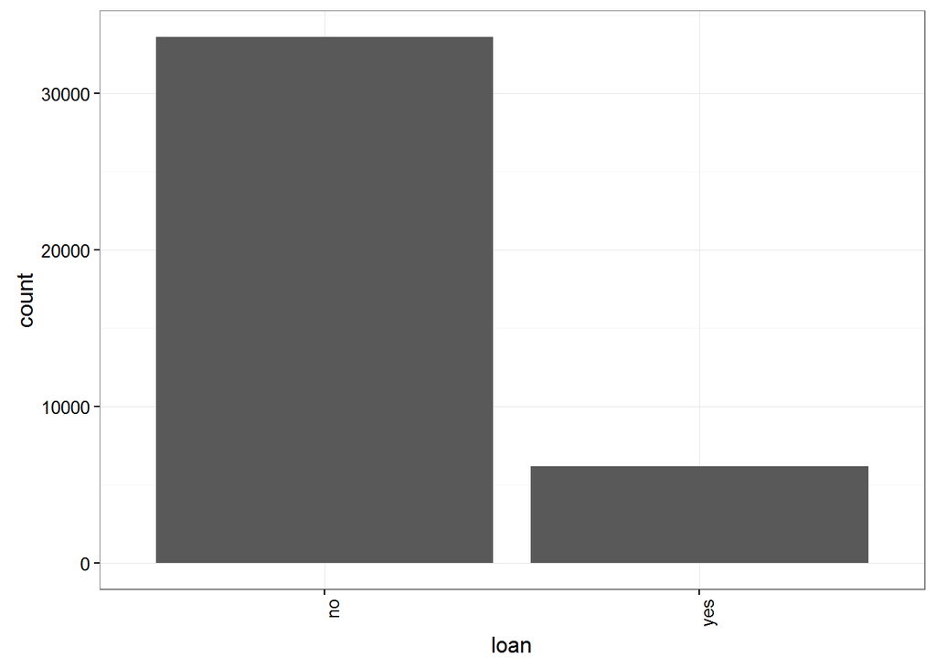

```r
ggplot(bank, aes(x = loan)) + geom_bar() + theme_bw() + theme(axis.text.x = element_text(angle = 90, hjust = 1))
```

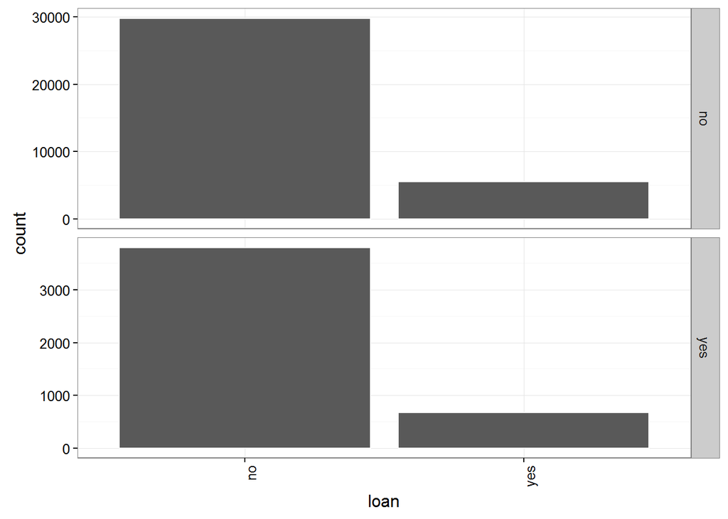

```r
ggplot(bank) + geom_bar(aes(x = loan), col = "white") +
  facet_grid(y~., scales = "free")  + theme_bw() + theme(axis.text.x = element_text(angle = 90, hjust = 1))
```

Let’s remove unknown again.

```r
bank <- bank %>% filter(loan != "unknown")
```

##### **Contact** (*categorical*)

This variable shows the contact communication type (cellular/telephone).

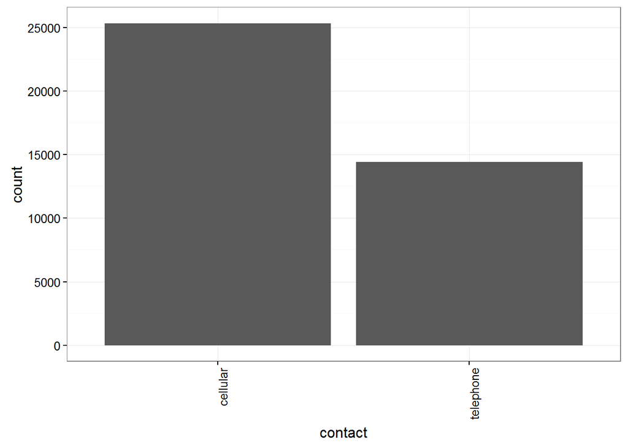

```r
ggplot(bank, aes(x = contact)) + geom_bar() + theme_bw() + theme(axis.text.x = element_text(angle = 90, hjust = 1))
```

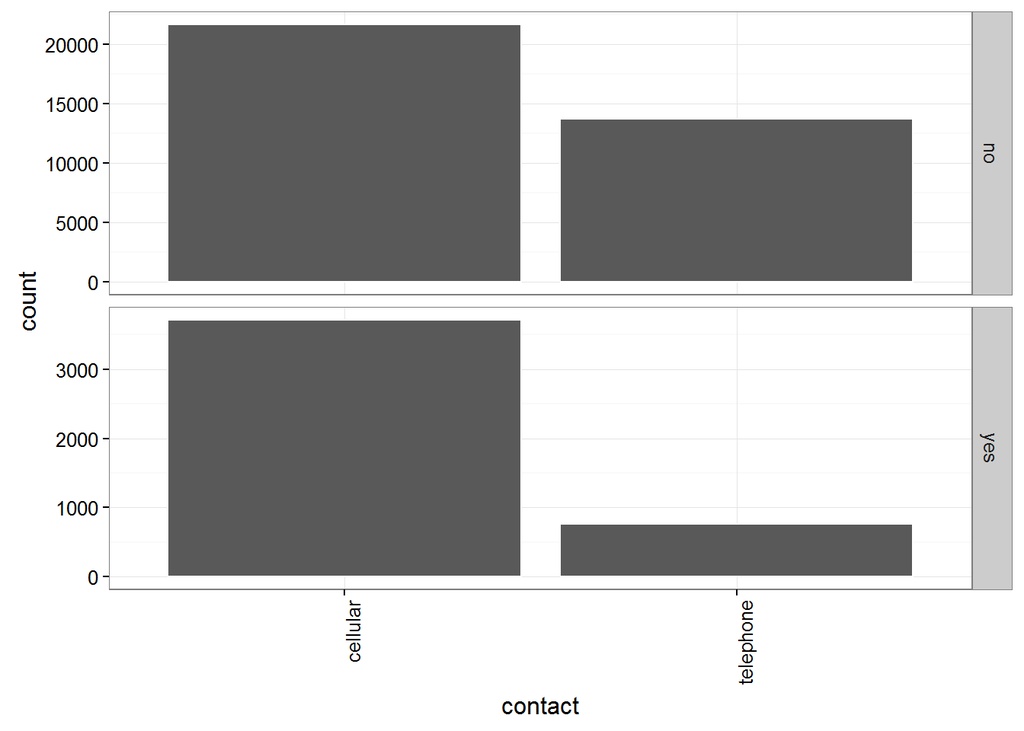

```r
ggplot(bank) + geom_bar(aes(x = contact), col = "white") +
  facet_grid(y~., scales = "free")  + theme_bw() + theme(axis.text.x = element_text(angle = 90, hjust = 1))
```

##### **Month** (*categorical*)

Last contact month of the year (cellular/telephone).

Order of months looks a bit strange, I admit. But it’s OK now for us (checking variables). Contact month seems to be a strong predictor - at least for current dataset. Keep it in mind (in order to avoid overfitting later).

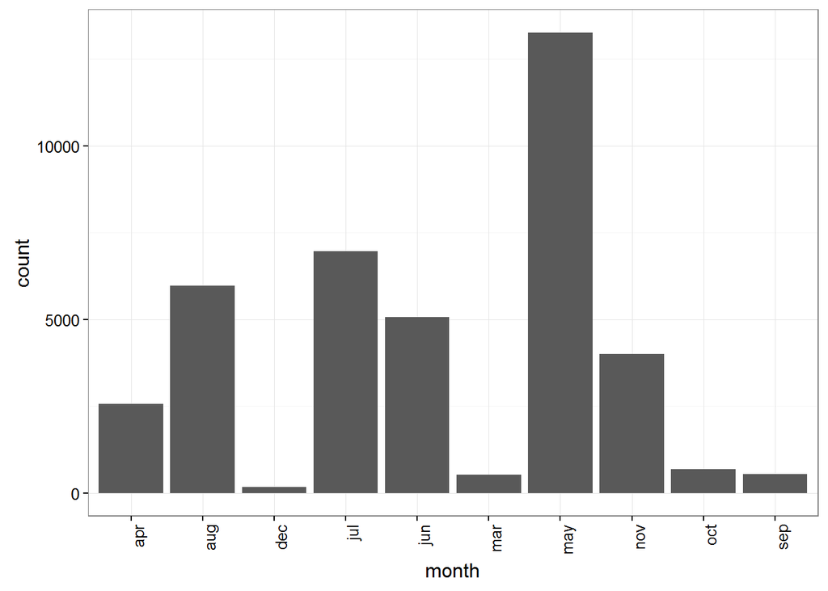

```r
ggplot(bank, aes(x = month)) + geom_bar() + theme_bw() + theme(axis.text.x = element_text(angle = 90, hjust = 1))
```

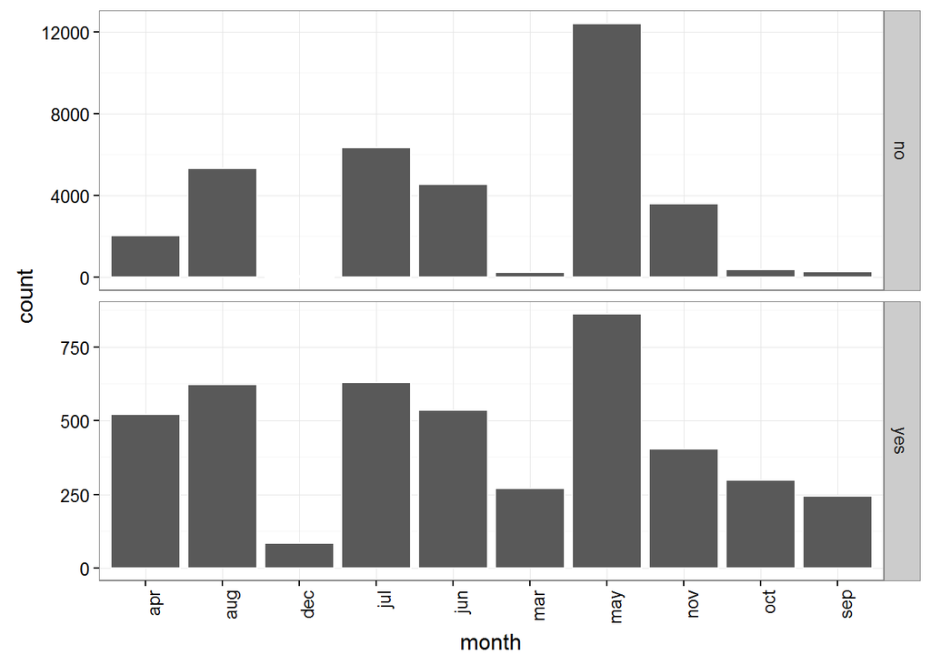

```r
ggplot(bank) + geom_bar(aes(x = month), col = "white") +
  facet_grid(y~., scales = "free")  + theme_bw() + theme(axis.text.x = element_text(angle = 90, hjust = 1))
```

##### **Day of week** (*categorical*)

Last contact day of the week (the 5 weekdays). Nothing special at first sight.

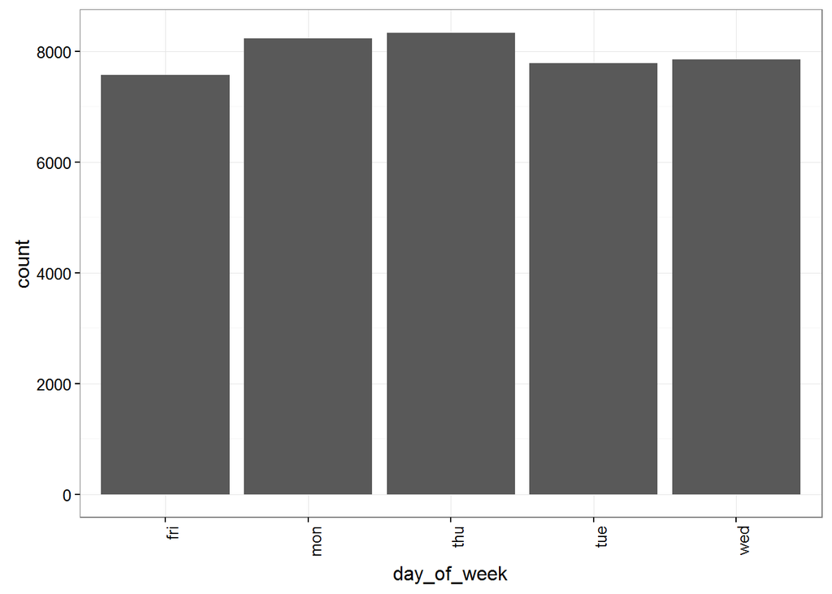

```r
ggplot(bank, aes(x = day_of_week)) + geom_bar() + theme_bw() + theme(axis.text.x = element_text(angle = 90, hjust = 1))
```

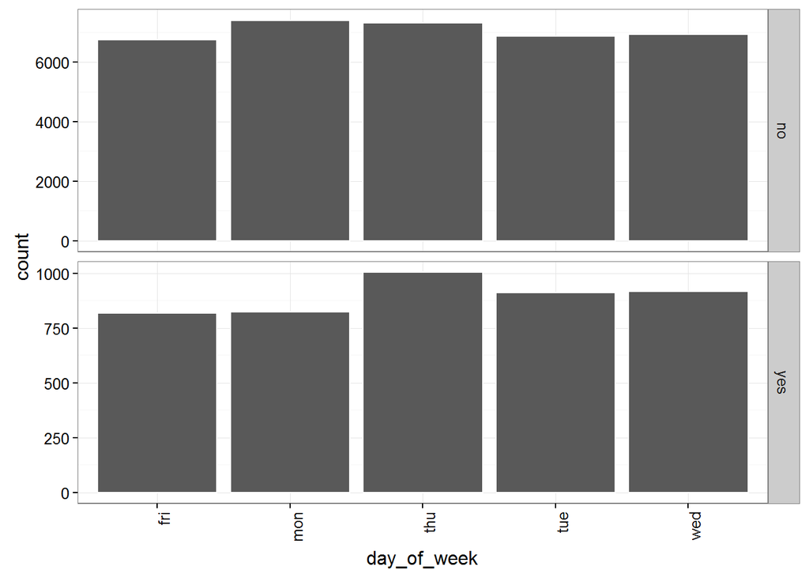

```r
ggplot(bank) + geom_bar(aes(x = day_of_week), col = "white") +
  facet_grid(y~., scales = "free")  + theme_bw() + theme(axis.text.x = element_text(angle = 90, hjust = 1))
```

##### **Duration** (*numeric*)

Last contact duration, in seconds. *Authors note: “this attribute highly affects the output target (e.g., if duration=0 then y=‘no’). Yet, the duration is not known before a call is performed. Also, after the end of the call y is obviously known. Thus, this input should only be included for benchmark purposes and should be discarded if the intention is to have a realistic predictive model.”*

Based on above I’m going to exclude this variable, however, it’s worth to see its distribution in itself.

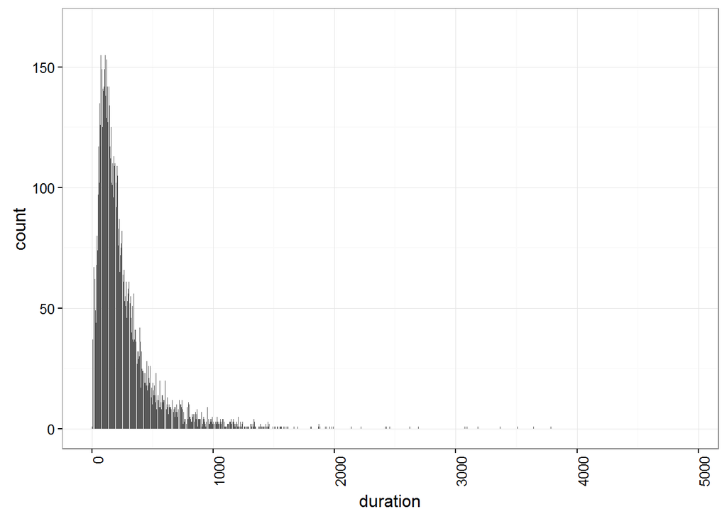

```r
ggplot(bank, aes(x = duration)) + geom_bar() + theme_bw() + theme(axis.text.x = element_text(angle = 90, hjust = 1))
```

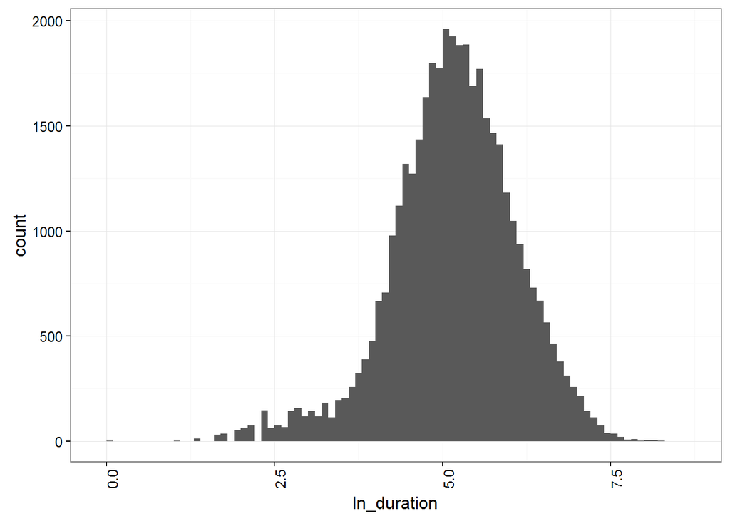

```r
ln_duration <- log(bank$duration)
ggplot(bank, aes(x = ln_duration)) + geom_histogram(binwidth = 0.1) + theme_bw() + theme(axis.text.x = element_text(angle = 90, hjust = 1))
```

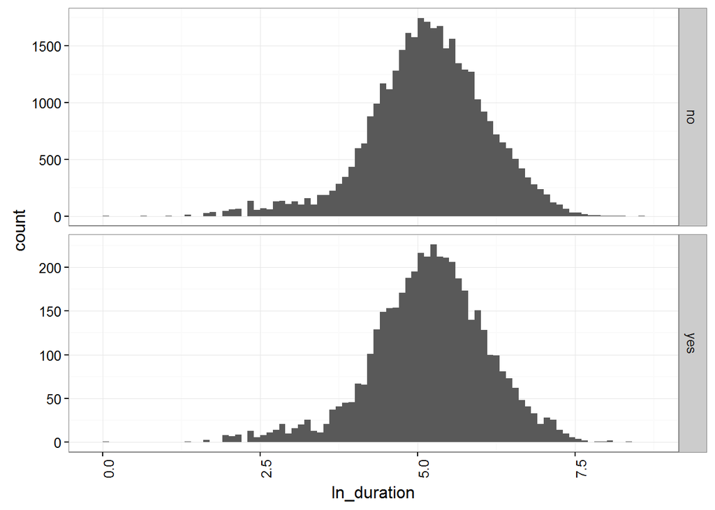

```r
ggplot(bank) + geom_histogram(aes(x = ln_duration), binwidth = 0.1) +
  facet_grid(y~., scales = "free")  + theme_bw() + theme(axis.text.x = element_text(angle = 90, hjust = 1))
```

##### **Campaign** (*numeric*)

Number of contacts performed during this campaign and for this client (including last contact). Campaign lasts for 10 months. I consider more than 10 contacts an issue or data error (vecause of probably applied contact rules). We have 0.8k observations with more than 10 contacts. I’m going to drop them as possible errors.

```r
summary(bank$campaign)
```

```
##    Min. 1st Qu.  Median    Mean 3rd Qu.    Max.
##   1.000   1.000   2.000   2.567   3.000  43.000
```

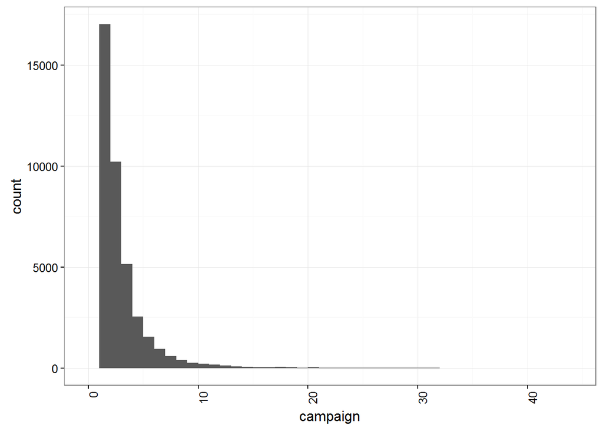

```r
ggplot(bank, aes(x = campaign)) + geom_histogram(binwidth = 1) + theme_bw() + theme(axis.text.x = element_text(angle = 90, hjust = 1))
```

```r
nrow(bank[bank$campaign > 10, ])
```

```
## [1] 837
```

```r
bank <- bank %>% filter(campaign < 10)
```

##### **Pdays** (*numeric*)

Number of days after the client was last contacted from a previous campaign (999 means client was not previously contacted). In most cases this variable gets 999 that’s why I won’t use it as a predictor.

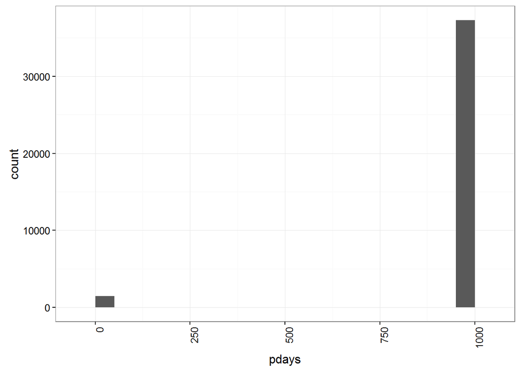

```r
ggplot(bank, aes(x = pdays)) + geom_histogram(binwidth = 50) + theme_bw() + theme(axis.text.x = element_text(angle = 90, hjust = 1))
```

##### **Previous** (*numeric*)

Number of contacts performed before this campaign and for this client. Seems to be a good predictor as customers may change their view as get used to be contacted.

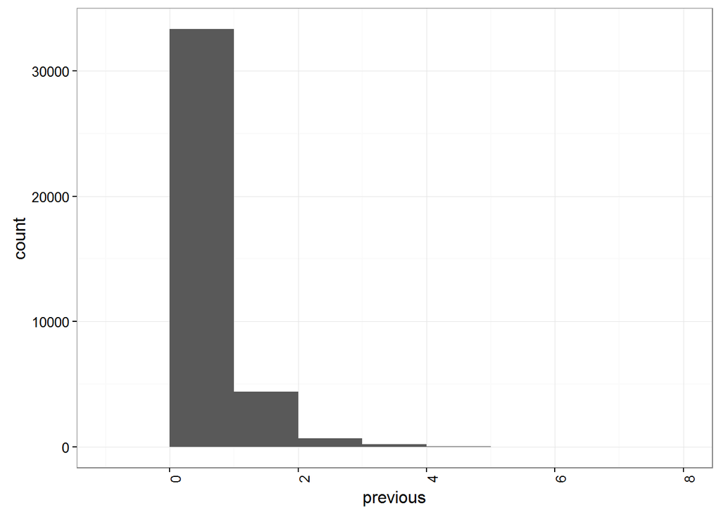

```r
ggplot(bank, aes(x = previous)) + geom_histogram(binwidth = 1) + theme_bw() + theme(axis.text.x = element_text(angle = 90, hjust = 1))
```

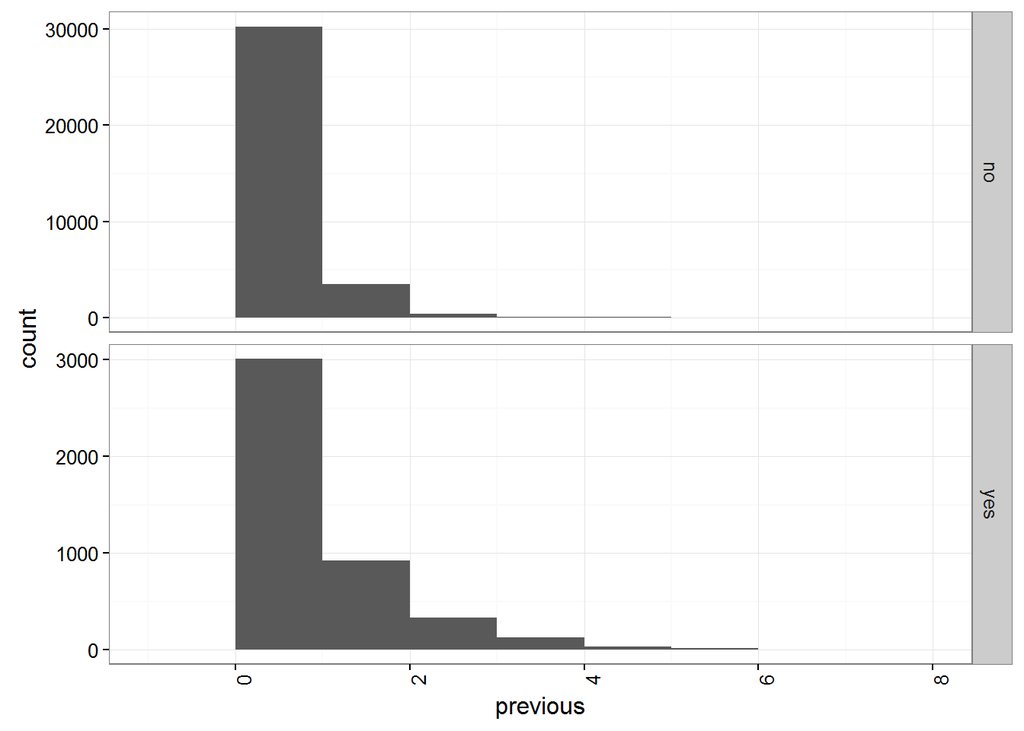

```r
ggplot(bank) + geom_histogram(aes(x = previous), binwidth = 1) +
  facet_grid(y~., scales = "free")  + theme_bw() + theme(axis.text.x = element_text(angle = 90, hjust = 1))
```

##### **Poutcome** (*categorical*)

This feature shows the outcome of the previous marketing campaign. Possible categories are the following: failure/nonexistent/success. As we can see by eyballing previous success shows a probable affinity for such campaigns, however, sample was too small to draw far-reaching conclusions.

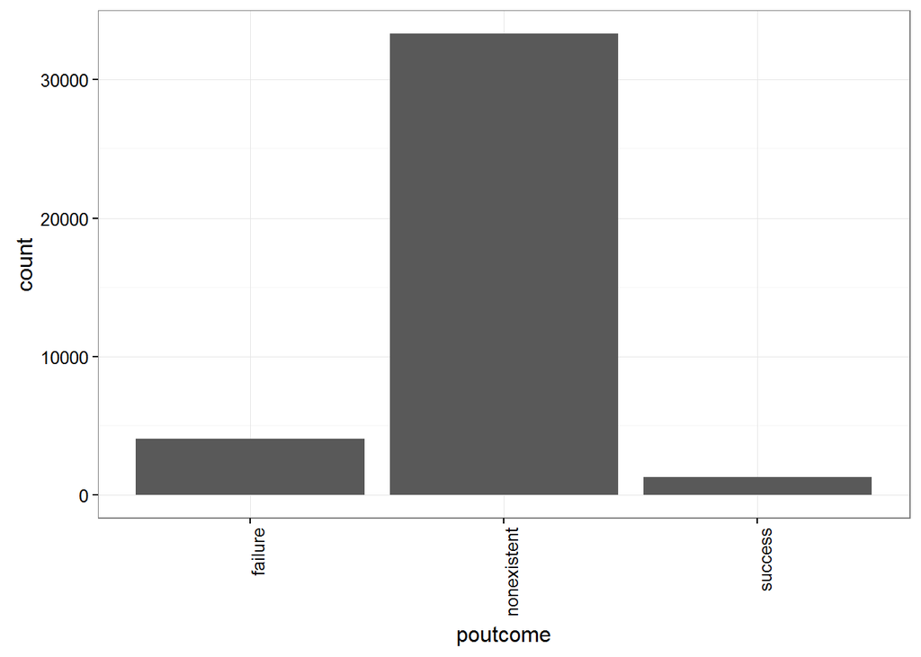

```r
ggplot(bank, aes(x = poutcome)) + geom_bar() + theme_bw() + theme(axis.text.x = element_text(angle = 90, hjust = 1))
```

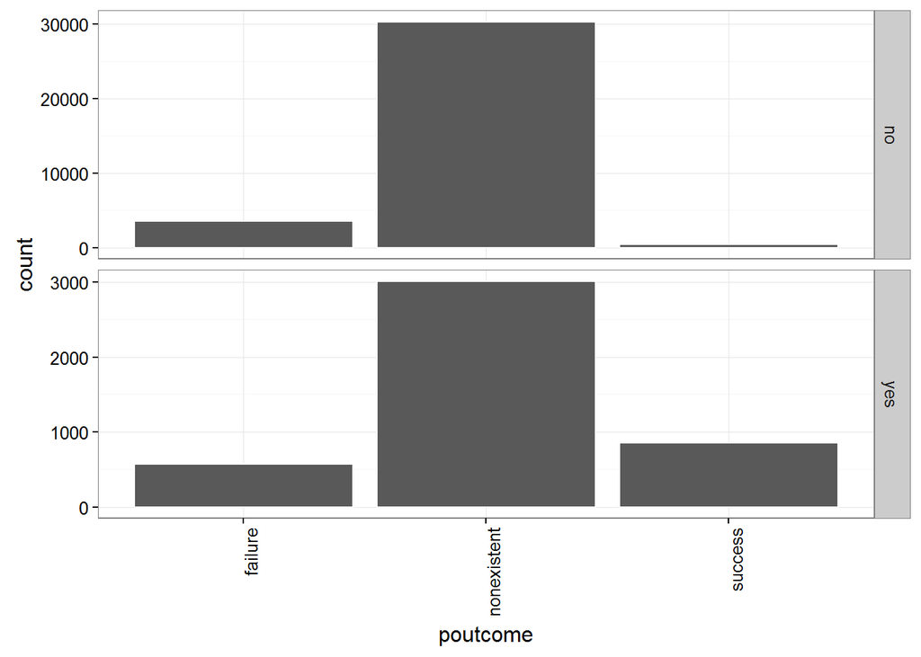

```r
ggplot(bank) + geom_bar(aes(x = poutcome), col = "white") +
  facet_grid(y~., scales = "free")  + theme_bw() + theme(axis.text.x = element_text(angle = 90, hjust = 1))
```